Predictive  
Analytics

# Dan Wigodsky

## Data 624 Project 2 data exploration

## April 14, 2019

```
## 'data.frame':    2559 obs. of  33 variables:
##  $ ph              : num  8.36 8.26 8.94 8.24 8.26 8.32 8.4 8.38 8.38 8.5 ...
##  $ brandcode       : Factor w/ 4 levels "A","B","C","D": 2 1 2 1 1 1 1 2 2 2 ...
##  $ carbvolume      : num  5.34 5.43 5.29 5.44 5.49 ...
##  $ fillounces      : num  24 24 24.1 24 24.3 ...
##  $ pcvolume        : num  0.263 0.239 0.263 0.293 0.111 ...
##  $ carbpressure    : num  68.2 68.4 70.8 63 67.2 66.6 64.2 67.6 64.2 72 ...
##  $ carbtemp        : num  141 140 145 133 137 ...
##  $ psc             : num  0.104 0.124 0.09 0.08 0.026 0.09 0.128 0.154 0.132 0.014 ...
##  $ pscfill         : num  0.26 0.22 0.34 0.42 0.16 ...
##  $ pscco2          : num  0.04 0.04 0.16 0.04 0.12 ...
##  $ mnfflow         : num  -100 -100 -100 -100 -100 -100 -100 -100 -100 -100 ...
##  $ carbpressure1   : num  119 122 120 115 118 ...
##  $ fillpressure    : num  46 46 46 46.4 45.8 45.6 51.8 46.8 46 45.2 ...
##  $ hydpressure1    : num  0 0 0 0 0 0 0 0 0 0 ...
```

[output cut: 19 more lines]

```
##
## Call:
## lm(formula = ph ~ ., data = beverage_set)
##
## Residuals:
##      Min       1Q   Median       3Q      Max
## -0.52528 -0.07682  0.01088  0.08729  0.40990
##
## Coefficients:
##                    Estimate Std. Error t value Pr(>|t|)
## (Intercept)       1.131e+01  1.079e+00  10.483  < 2e-16 ***
## brandcodeB        9.154e-02  2.134e-02   4.290 1.85e-05 ***
## brandcodeC       -3.882e-02  2.114e-02  -1.836 0.066482 .
## brandcodeD        5.160e-02  1.764e-02   2.925 0.003477 **
## carbvolume       -1.627e-01  8.954e-02  -1.817 0.069384 .
## fillounces       -8.466e-02  3.211e-02  -2.637 0.008419 **
## pcvolume         -1.103e-01  5.416e-02  -2.036 0.041872 *
## carbpressure      4.525e-03  4.181e-03   1.082 0.279165
## carbtemp         -2.706e-03  3.296e-03  -0.821 0.411810
## psc              -6.781e-02  5.665e-02  -1.197 0.231407
## pscfill          -2.693e-02  2.316e-02  -1.163 0.245072
## pscco2           -1.397e-01  6.262e-02  -2.231 0.025789 *
## mnfflow          -7.376e-04  4.595e-05 -16.053  < 2e-16 ***
## carbpressure1     6.402e-03  6.933e-04   9.234  < 2e-16 ***
## fillpressure      1.408e-03  1.213e-03   1.160 0.245989
## hydpressure1     -5.345e-05  3.638e-04  -0.147 0.883203
## hydpressure2     -1.192e-03  5.317e-04  -2.243 0.025000 *
## hydpressure3      3.552e-03  5.832e-04   6.091 1.29e-09 ***
## hydpressure4      2.513e-05  3.145e-04   0.080 0.936311
## fillerlevel      -1.043e-03  5.648e-04  -1.847 0.064833 .
## fillerspeed       1.414e-05  1.017e-05   1.391 0.164433
## temperature      -1.517e-02  2.294e-03  -6.612 4.61e-11 ***
## usagecont        -7.082e-03  1.134e-03  -6.243 5.04e-10 ***
## carbflow          9.638e-06  3.767e-06   2.558 0.010571 *
## density          -1.185e-01  2.777e-02  -4.266 2.06e-05 ***
## mfr              -3.710e-05  5.680e-05  -0.653 0.513728
## balling          -1.402e-01  2.571e-02  -5.453 5.44e-08 ***
## pressurevacuum   -3.169e-02  7.897e-03  -4.013 6.16e-05 ***
## oxygenfiller     -3.259e-01  7.129e-02  -4.571 5.09e-06 ***
## bowlsetpoint      3.109e-03  5.934e-04   5.240 1.74e-07 ***
## pressuresetpoint -7.525e-03  1.956e-03  -3.847 0.000122 ***
## airpressurer     -2.073e-03  2.351e-03  -0.882 0.377972
## alchrel           8.704e-02  2.659e-02   3.273 0.001077 **
## carbrel           3.427e-02  4.789e-02   0.715 0.474399
## ballinglvl        1.783e-01  2.599e-02   6.859 8.68e-12 ***
## ---
## Signif. codes:  0 '***' 0.001 '**' 0.01 '*' 0.05 '.' 0.1 ' ' 1
##
## Residual standard error: 0.1315 on 2524 degrees of freedom
## Multiple R-squared:  0.4198, Adjusted R-squared:  0.412
## F-statistic: 53.71 on 34 and 2524 DF,  p-value: < 2.2e-16
```

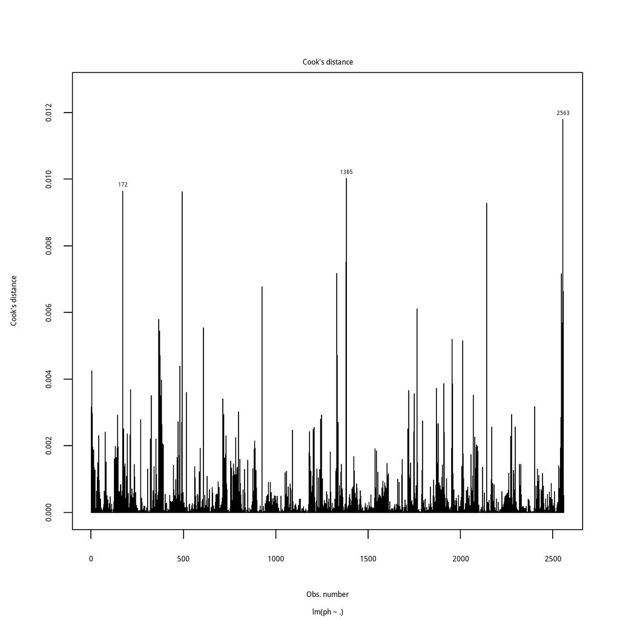

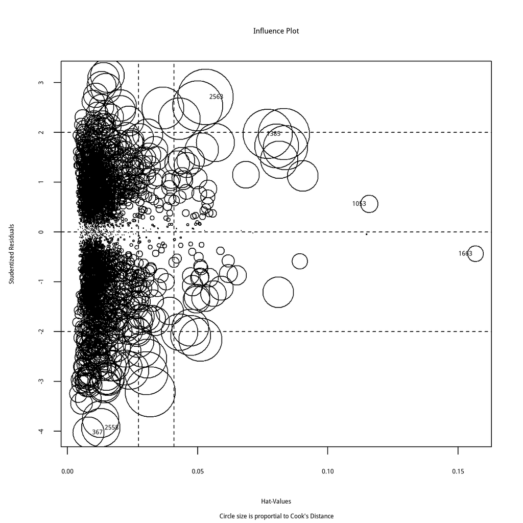

```
##         StudRes         Hat       CookD
## 367  -4.0225565 0.008129113 0.003766344
## 1053  0.5659909 0.115933713 0.001200584
## 1385  1.9688968 0.083111426 0.010028301
## 1663 -0.4356054 0.156719845 0.001007883
## 2558 -3.9294879 0.012825027 0.005698891
## 2563  2.7177927 0.053115006 0.011808293
```

```
##        ph brandcode carbvolume fillounces  pcvolume carbpressure carbtemp   psc pscfill pscco2 mnfflow carbpressure1 fillpressure hydpressure1 hydpressure2 hydpressure3 hydpressure4 fillerlevel
## 1096 8.42         C   5.253333      24.04 0.3053333           68    144.4 0.032    0.06   0.06  -100.2           129         59.6            0          0.2            0           88       161.2
##      fillerspeed temperature usagecont carbflow density   mfr balling pressurevacuum oxygenfiller bowlsetpoint pressuresetpoint airpressurer alchrel carbrel ballinglvl
## 1096        2062        68.6     18.28      394       1 397.6   1.698           -5.4         0.12          120               46        142.6    6.62    5.34       1.36
```

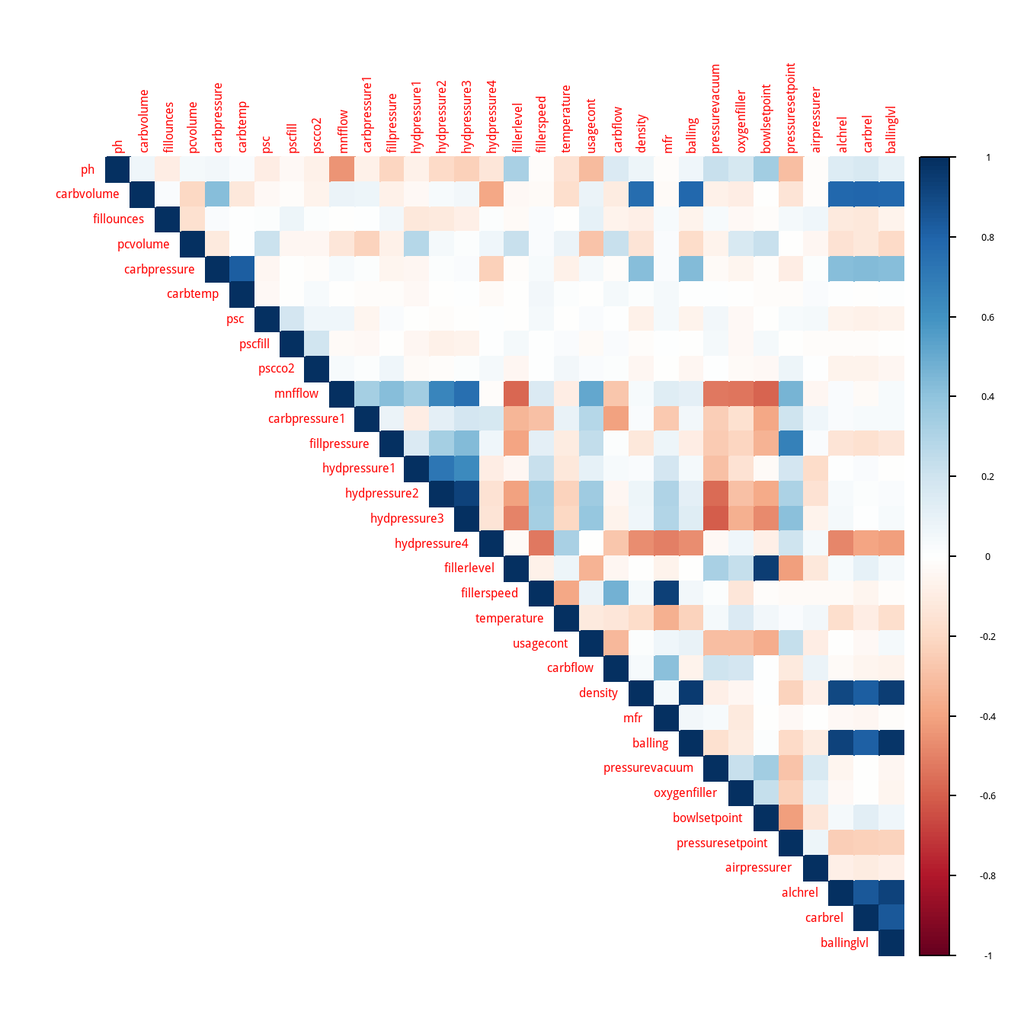

We check the variables for multi-collinearity. Since some had levels and accounted for more then one df, gvif was used intead of vif. The threshold should be 25 or 100. None of our variables passed this threshold.

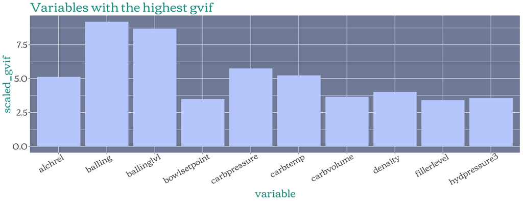

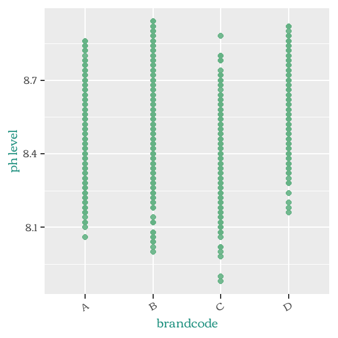

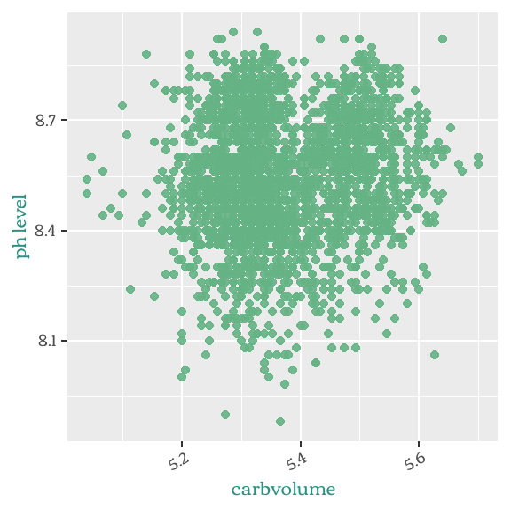

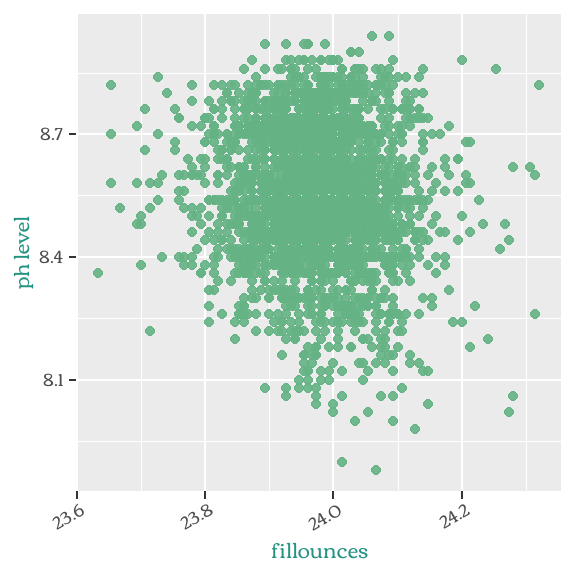

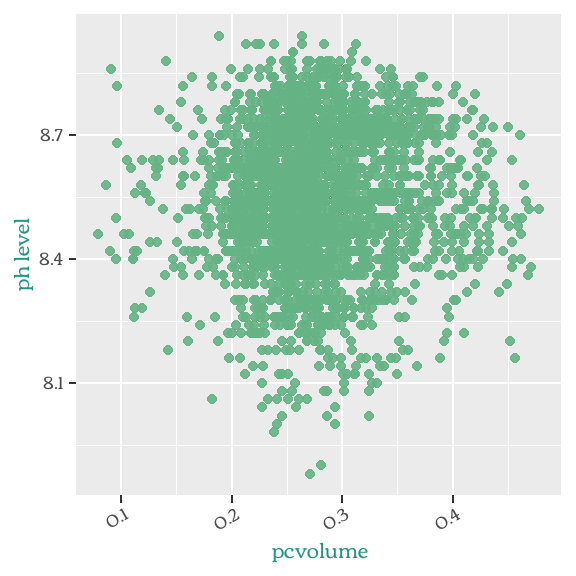

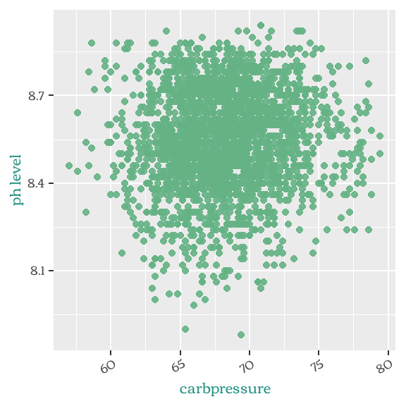

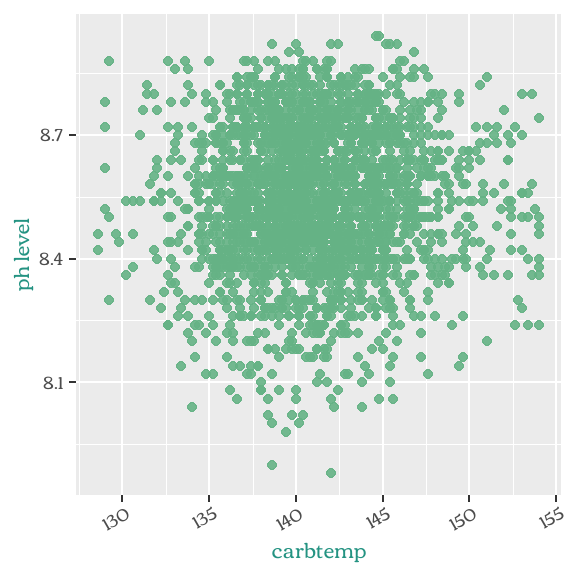

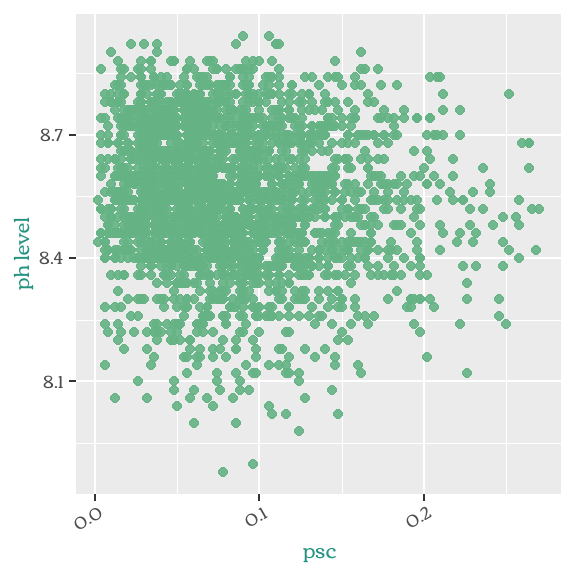

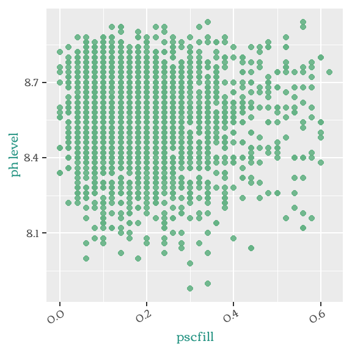

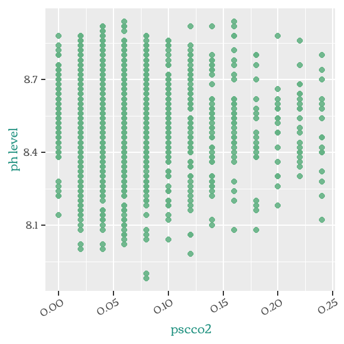

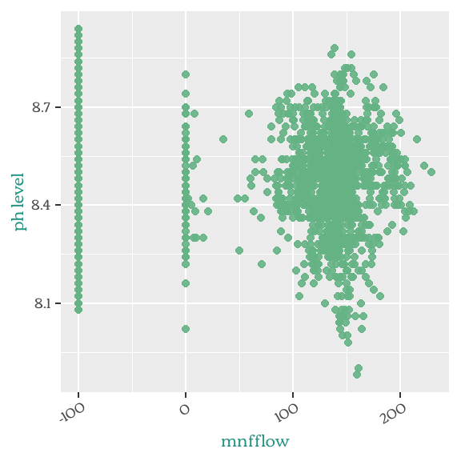

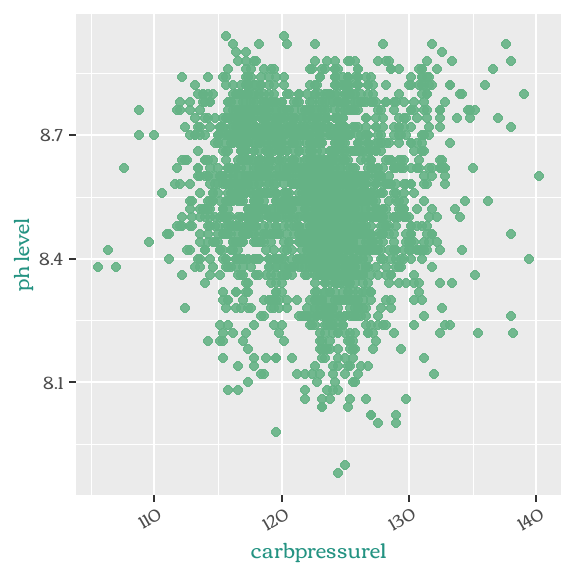

[21 more figures not shown]

We look for a kmeans clustering augmented regression model. #NOTE: This needs further refining. A better set of regression vars should be set by forward selection first.

```
## [[1]]
## [1] 0.4130912
##
## [[2]]
## [1] 0.4144582
##
## [[3]]
## [1] 0.4162478
##
## [[4]]
## [1] 0.4158973
##
## [[5]]
## [1] 0.4130551
##
## [[6]]
## [1] 0.4155212
##
## [[7]]
## [1] 0.4150387
##
## [[8]]
## [1] 0.4131184
##
## [[9]]
## [1] 0.4131884
##
## [[10]]
## [1] 0.4205172
##
## [[11]]
## [1] 0.4141224
##
## [[12]]
## [1] 0.4131623
##
## [[13]]
## [1] 0.4138712
##
## [[14]]
## [1] 0.413103
##
## [[15]]
## [1] 0.4150846
##
## [[16]]
## [1] 0.4130178
##
## [[17]]
## [1] 0.4132144
##
## [[18]]
## [1] 0.4164177
##
## [[19]]
## [1] 0.418695
##
## [[20]]
## [1] 0.4138122
```

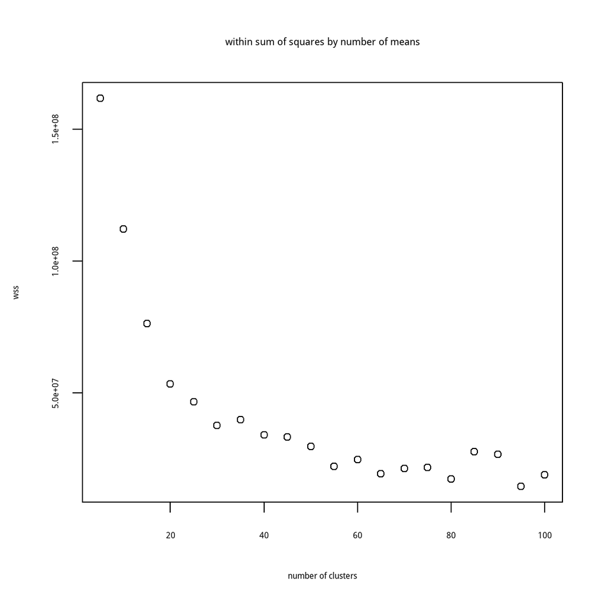

```
## [1] 0.1305528
```

This will be RMSE of basic multi-regression as benchmark

#NOTE: FORWARD STEPWISE SHOULD BE ADDED

```
##
## Call:
## lm(formula = ph ~ ., data = training_set)
##
## Residuals:
##      Min       1Q   Median       3Q      Max
## -0.52792 -0.07675  0.00940  0.08656  0.40575
##
## Coefficients:
##                    Estimate Std. Error t value Pr(>|t|)
## (Intercept)       1.176e+01  1.232e+00   9.545  < 2e-16 ***
## brandcodeB        1.040e-01  2.392e-02   4.350 1.43e-05 ***
## brandcodeC       -1.879e-02  2.344e-02  -0.802 0.422914
## brandcodeD        4.749e-02  1.981e-02   2.397 0.016618 *
## carbvolume       -1.525e-01  1.006e-01  -1.516 0.129578
## fillounces       -9.412e-02  3.578e-02  -2.631 0.008591 **
## pcvolume         -1.469e-01  6.034e-02  -2.434 0.015005 *
## carbpressure      4.591e-03  4.773e-03   0.962 0.336191
## carbtemp         -2.624e-03  3.762e-03  -0.697 0.485586
## psc              -3.023e-02  6.373e-02  -0.474 0.635326
## pscfill          -3.313e-02  2.605e-02  -1.272 0.203682
## pscco2           -1.986e-01  7.117e-02  -2.791 0.005310 **
## mnfflow          -7.549e-04  5.256e-05 -14.363  < 2e-16 ***
## carbpressure1     6.664e-03  7.732e-04   8.619  < 2e-16 ***
## fillpressure      5.052e-04  1.367e-03   0.370 0.711763
## hydpressure1      2.946e-05  4.069e-04   0.072 0.942297
## hydpressure2     -1.241e-03  5.875e-04  -2.113 0.034763 *
## hydpressure3      3.660e-03  6.624e-04   5.526 3.71e-08 ***
## hydpressure4     -1.667e-04  3.480e-04  -0.479 0.631897
## fillerlevel      -9.326e-04  6.399e-04  -1.457 0.145164
## fillerspeed       1.765e-05  1.128e-05   1.565 0.117806
## temperature      -1.711e-02  2.648e-03  -6.461 1.30e-10 ***
## usagecont        -6.894e-03  1.266e-03  -5.447 5.75e-08 ***
## carbflow          1.103e-05  4.254e-06   2.592 0.009605 **
## density          -1.089e-01  3.112e-02  -3.500 0.000476 ***
## mfr              -5.464e-05  6.332e-05  -0.863 0.388301
## balling          -1.587e-01  2.897e-02  -5.479 4.82e-08 ***
## pressurevacuum   -3.081e-02  8.839e-03  -3.486 0.000501 ***
## oxygenfiller     -3.894e-01  8.160e-02  -4.772 1.96e-06 ***
## bowlsetpoint      2.993e-03  6.682e-04   4.479 7.92e-06 ***
## pressuresetpoint -6.674e-03  2.212e-03  -3.017 0.002583 **
## airpressurer     -2.649e-03  2.637e-03  -1.005 0.315219
## alchrel           8.886e-02  3.046e-02   2.918 0.003566 **
## carbrel           1.138e-02  5.421e-02   0.210 0.833739
## ballinglvl        2.005e-01  2.948e-02   6.802 1.36e-11 ***
## ---
## Signif. codes:  0 '***' 0.001 '**' 0.01 '*' 0.05 '.' 0.1 ' ' 1
##
## Residual standard error: 0.132 on 2013 degrees of freedom
## Multiple R-squared:  0.423,  Adjusted R-squared:  0.4133
## F-statistic: 43.41 on 34 and 2013 DF,  p-value: < 2.2e-16
```

```
##                    ME      RMSE      MAE        MPE     MAPE
## Test set -0.004674015 0.1308541 0.101792 -0.0776606 1.196723
```

Clustering enhanced the regression performance with the validation set, but only slightly Even more performance was achieved by choosing variables for the clustering analysis. Variables were chosen by VIF, by scatterplot, and corrplot. In the scatterplot, variables were chosen that appeared to have a combination of dicrete levels and difference between levels. In the corrplot, variables with fairly high absolute value correlation with other indep. variables were chosen. (3,17,21,23,25,30,31,33,7,16) - RMSE = .1305528 vs. RMSE = .1307519

An elastic net model is attempted with the glmnet to try lasso/ridge regressions. Both shrink the effects of betas. The lasso selects features and does shrinkage. The glmnet mixes between the two models.

#NOTE: change brand to numeric

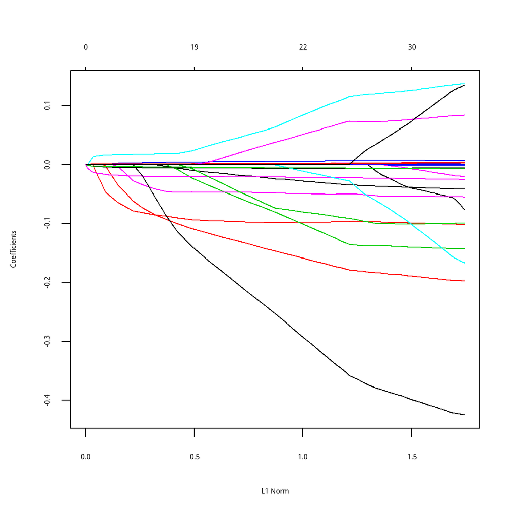

```
## [1] 0.1428975
```

source for Cook’s distance plot: https://www.statmethods.net/stats/rdiagnostics.html gvif cutoff: https://stats.stackexchange.com/questions/70679/which-variance-inflation-factor-should-i-be-using-textgvif-or-textgvif –answer by fox